# respostas

## Teste Técnico de Engenharia de Dados - William Ávila Hellwig

#### Para a presente análise, as unidades de distância e valor monetário correspondem a, respectivamente, quilômetro e dólar.

### Respostas aos quesitos mínimos

### Questão 1

A partir da base de dados disponibilizada, excluiu-se da análise corridas em que não foram registrados passageiros, e corridas que apresentam na base de dados distâncias de 0 km a fim de evitar interferências no valor da média. Pela figura abaixo, nota-se que a distribuição das distâncias das corridas com no máximo dois passageiros apresentou uma mesma distribuição para todos os anos analisados. A média correspondente para cada ano, e portanto para todo o período, foi avaliada em 2,688 km.

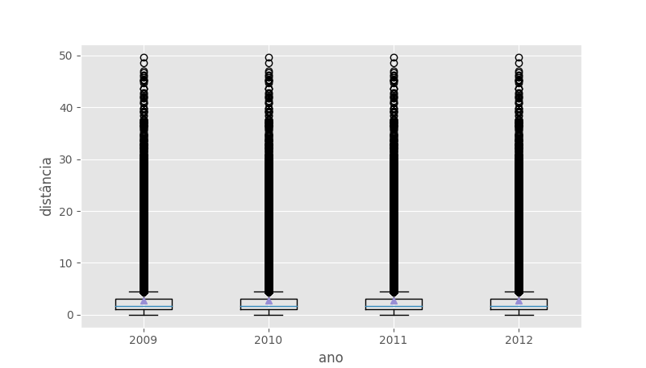

### Questão 2

Com base nos dados analisados, verificou-se a seguinte distribuição de receita por fornecedor.

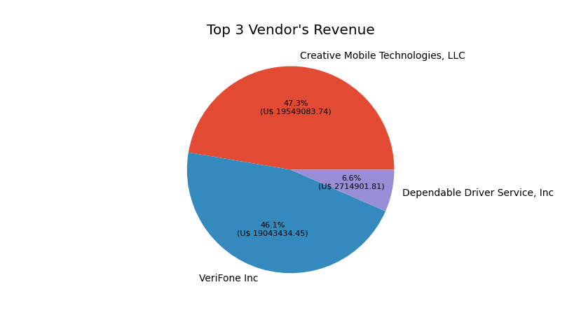

### Questão 3

A distribuição mensal das corridas para os últimos quatro anos pode ser analisada pela figura abaixo. Inicialmente, a distribuição foi realizada tendo como base todo o período disponível. Dessa análise prévia, verificou-se uma redução considerável nas corridas dos últimos meses do ano. De modo a entender o motivo para essa redução, foi realizada a distribuição mensal para cada ano. Conclui-se que essa redução está relacionada majoritariamente à carência de dados referente aos anos de 2011 e 2012 para os meses de novembro e dezembro e à ausência de informações para a metade do mês de dezembro para os outros anos.

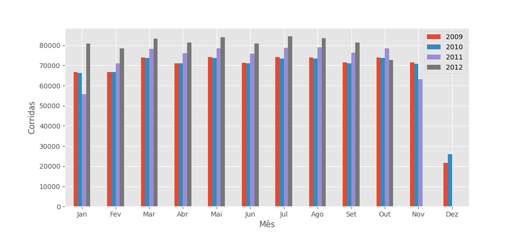

### Questão 4

A avaliação temporal da distribuição de gorjetas por dia para o último trimestre do ano de 2012 é representada pela figura abaixo. Para a presente análise, desconsiderou-se as ocorrências de corridas sem passageiros. Como observado pela distribuição da questão anterior, constata-se novamente a ausência de dados para os meses de novembro e dezembro para o ano de 2012.

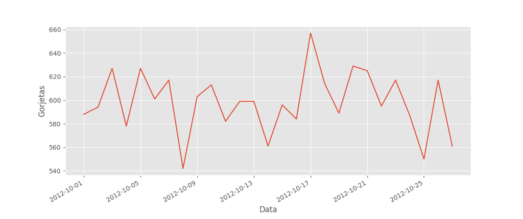

### Respostas aos quesitos bônus

### Tópico primeiro

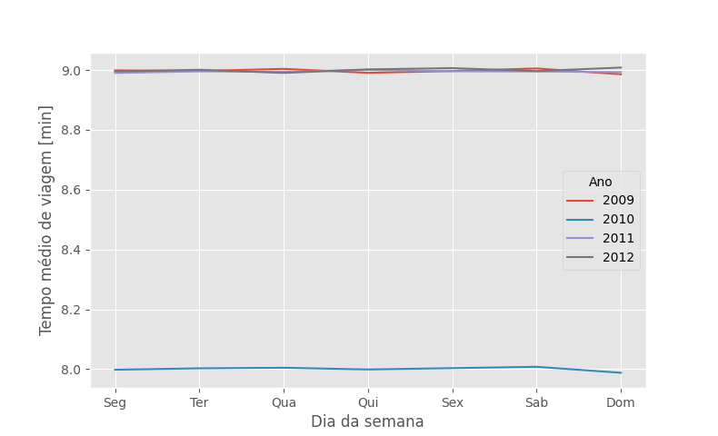

### Tópico segundo

Para iniciar a avaliação a posição geográfica dos pontos de embarque e desembarque das corridas, um gráfico das latitudes e longitudes de cada par distinto de coordenadas foi plotado para uma primeira análise. O gráfico se apresenta na figura abaixo.

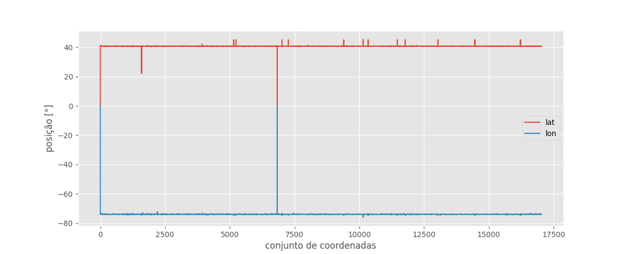

A partir do gráfico, verificou-se que há pontos que não correspondem à realidade das corridas. Para o mapa gerado, todas as coordenadas foram mantidas tendo em mente tais distorções. Na figura abaixo pode-se ver uma imagem centralizada na cidade de Nova Iorque, região que apresenta a maior incidência de corridas.

[figure not shown]